# FIAP TECH CHALLENGE 1 - GRUPO SSP

## 2. ANÁLISE DOS DADOS

### 2.1. Estabelecendo a variável `BASE_PATH`

```python
import pandas as pd
from pathlib import Path

# Considerando que o Notebook está sendo rodado em /src/notebooks/
BASE_PATH = Path.cwd().resolve().parent.parent
print(f"📁 Base path: {BASE_PATH.absolute()}")
```

```
📁 Base path: /Users/matias/Projetos/fiap/tech-challenge-1
```

### 2.2. Gerando um Dataframe único com todos os arquivos parquet concatenados

```python
# Carregar todos os arquivos parquet do diretório
parquet_dir = BASE_PATH / "data" / "raw" / "VIOLBR24.parquet"

# Lista todos os arquivos .parquet no diretório
parquet_files = list(parquet_dir.glob("*.parquet"))
print(f"📊 Encontrados {len(parquet_files)} arquivos parquet")

# Carrega cada arquivo parquet e combina em um único dataframe
dfs = []
for parquet_file in parquet_files:
    df = pd.read_parquet(parquet_file)
    dfs.append(df)
    # print(f"✓ Carregado: {parquet_file.name} ({len(df)} linhas)")

# Concatena todos os dataframes
df = pd.concat(dfs, ignore_index=True)
print(f"\n✅ DataFrame final criado com {len(df)} linhas e {len(df.columns)} colunas")
```

```
📊 Encontrados 23 arquivos parquet

✅ DataFrame final criado com 662803 linhas e 160 colunas
```

### 2.3. Aplicando filtros para delimitar escopo

Filtros Aplicados:

- Sexo Feminino
- Lesões que não sejam autoprovacadas

```python
filter = (
    (df['CS_SEXO'] == 'F') &
    (df['LES_AUTOP'] == '2')
)
filtered_df = df[filter].copy()
```

```python
# Visualização inicial do dataframe
print("📋 Informações do DataFrame:")
print(f"Shape: {filtered_df.shape}")
print(f"\nColunas ({len(filtered_df.columns)}):")
print(filtered_df.columns.tolist())
print(f"\nTipos de dados:")
print(filtered_df.dtypes)
print(f"\nPrimeiras linhas:")
filtered_df.head()
```

```
📋 Informações do DataFrame:
Shape: (294393, 160)

Colunas (160):
['TP_NOT', 'ID_AGRAVO', 'DT_NOTIFIC', 'SEM_NOT', 'NU_ANO', 'SG_UF_NOT', 'ID_MUNICIP', 'ID_UNIDADE', 'DT_OCOR', 'SEM_PRI', 'ANO_NASC', 'NU_IDADE_N', 'CS_SEXO', 'CS_GESTANT', 'CS_RACA', 'CS_ESCOL_N', 'SG_UF', 'ID_MN_RESI', 'ID_PAIS', 'NDUPLIC', 'DT_INVEST', 'ID_OCUPA_N', 'SIT_CONJUG', 'DEF_TRANS', 'DE…

Tipos de dados:
TP_NOT        object
ID_AGRAVO     object
DT_NOTIFIC    object
SEM_NOT       object
NU_ANO        object
               ...
DELEG_MULH    object
DELEG         object
INFAN_JUV     object
DEFEN_PUBL    object
DT_ENCERRA    object
Length: 160, dtype: object

Primeiras linhas:
```

|  | TP_NOT | ID_AGRAVO | DT_NOTIFIC | SEM_NOT | NU_ANO | SG_UF_NOT | ID_MUNICIP | ID_UNIDADE | DT_OCOR | SEM_PRI | ... | CONS_IDO | DELEG_IDOS | DIR_HUMAN | MPU | DELEG_CRIA | DELEG_MULH | DELEG | INFAN_JUV | DEFEN_PUBL | DT_ENCERRA |
| --- | --- | --- | --- | --- | --- | --- | --- | --- | --- | --- | --- | --- | --- | --- | --- | --- | --- | --- | --- | --- | --- |
| 0 | 2 | Y09 | 20240610 | 202424 | 2024 | 29 | 292740 | 0004081 | 20240418 | 202416 | ... | 2 | 2 | 2 | 2 | 2 | 2 | 2 | 2 | 2 | 20240610 |
| 1 | 2 | Y09 | 20240610 | 202424 | 2024 | 29 | 291920 | 2802023 | 20240602 | 202423 | ... | 2 | 2 | 2 | 2 | 2 | 2 | 2 | 2 | 2 | 20240618 |
| 4 | 2 | Y09 | 20240610 | 202424 | 2024 | 35 | 353440 | 0008036 | 20240604 | 202423 | ... | 2 | 2 | 2 | 2 | 2 | 2 | 2 | 2 | 2 | 20240610 |
| 5 | 2 | Y09 | 20240610 | 202424 | 2024 | 35 | 355030 | 2752042 | 20240608 | 202423 | ... | 9 | 9 | 9 | 9 | 9 | 9 | 9 | 9 | 9 | 20240705 |
| 6 | 2 | Y09 | 20240610 | 202424 | 2024 | 41 | 412350 | 4056000 | 20240610 | 202424 | ... | 2 | 2 | 2 | 2 | 2 | 2 | 2 | 2 | 2 | 20240814 |

5 rows × 160 columns

```python
import json

# Carregar o dicionário de campos
dicionario_path = BASE_PATH / "src" / "data" / "dicionario_campos_sinan.json"
with open(dicionario_path, 'r', encoding='utf-8') as f:
    dicionario = json.load(f)

# Filtrar campos com relevante = True
campos_relevantes = [
    campo for campo, info in dicionario.items()
    if info.get('relevante', False) == True
]

# Filtrar apenas as colunas que existem no dataframe
colunas_existentes = [col for col in campos_relevantes if col in filtered_df.columns]
colunas_nao_existentes = [col for col in campos_relevantes if col not in filtered_df.columns]

if colunas_nao_existentes:
    print(f"\n⚠️  Aviso: {len(colunas_nao_existentes)} campos do dicionário não existem no dataframe:")
    print(colunas_nao_existentes)


# Criar subconjunto do dataframe com apenas as colunas relevantes
df_relevante = filtered_df[colunas_existentes].copy()

print(f"\n✅ DataFrame com campos relevantes criado:")
print(f"   Shape: {df_relevante.shape}")
```

```
✅ DataFrame com campos relevantes criado:
   Shape: (294393, 79)
```

```python
# Valores null/NaN
valores_null = df_relevante.isna().sum()

# Strings vazias ou com apenas espaços
valores_string_vazia = df_relevante.apply(
    lambda col: (col.astype(str).str.strip() == '').sum()
)

# print(f'valores_null: {valores_null}')
# print(f'valores_string_vazia: {valores_string_vazia}')

# dataframes com valores null e valores string vazia
# valores_vazio_df = pd.concat([valores_null, valores_string_vazia], axis=1, keys=['null', 'string_vazia'])
# print(valores_vazio_df)

# printar somente LESAO_ESPE (linhas = campos, colunas = tipo de vazio)
# print(valores_vazio_df.loc['LESAO_ESPE'])

# Total combinado
valores_vazios = valores_null + valores_string_vazia

percentual_vazios = (valores_vazios / len(df_relevante)) * 100
# formatar percentual_vazios em 2 decimais
percentual_vazios = percentual_vazios.round(5)
# ordenar percentual_vazios de forma decrescente
percentual_vazios = percentual_vazios.sort_values(ascending=False)

# print(f'valores_vazios (total): {valores_vazios}')

print(f'percentual_vazios: {percentual_vazios}')
```

```
percentual_vazios: TPUNINOT      100.00000
ENC_ESPEC      99.99864
LESAO_ESPE     99.99796
LESAO_CORP     99.99185
LESAO_NAT      99.99049
                ...
SG_UF           0.01155
ID_AGRAVO       0.00000
CS_SEXO         0.00000
LES_AUTOP       0.00000
DT_OCOR         0.00000
Length: 79, dtype: float64
```

```python
# criar dataframe em que as colunas são as que tem menos de 10% de vazios
cleaned_df = df_relevante.loc[:, percentual_vazios < 10]
# print(cleaned_df.shape)
# print(cleaned_df.columns)
# print(cleaned_df.head())

# recalcular percentual de vazios
ev2 = cleaned_df.apply(
    lambda col: (col.astype(str).str.strip() == '').sum()
)
pv2 = (ev2 / len(cleaned_df)) * 100
pv2 = pv2.round(2)
pv2 = pv2.sort_values(ascending=False)

print(f'percentual_vazios: {pv2}')

# print quantidade de colunas do dataframe atual
print(f'quantidade de colunas do dataframe atual: {len(cleaned_df.columns)}')

# salvar em data/processed/df_cleaned.parquet
cleaned_df.to_parquet(BASE_PATH / "data" / "processed" / "df_cleaned.parquet")
```

```
percentual_vazios: CS_ESCOL_N    3.36
AG_AMEACA     1.96
CONS_TUTEL    1.53
ATEND_MULH    1.52
REL_CUIDA     1.44
REL_POL       1.44
REL_PATRAO    1.44
REL_MAD       1.44
REL_INST      1.44
REL_PROPRI    1.43
REL_PAD       1.42
REL_IRMAO     1.42
REL_FILHO     1.42
REL_EXNAM     1.42
REL_TRAB      1.41
REL_OUTROS    1.40
REL_NAMO      1.40
REL_DESCO     1.39
REL_EXCON     1.36
REL_CONHEC    1.33
VIOL_OUTR     1.30
VIOL_LEGAL    1.29
VIOL_INFAN    1.29
VIOL_TRAF     1.29
VIOL_FINAN    1.28
VIOL_TORT     1.27
REL_CONJ      1.26
VIOL_PSICO    1.21
REL_PAI       1.20
SIT_CONJUG    1.18
VIOL_SEXU     1.14
REL_MAE       1.12
DEF_OUT       1.05
DEF_VISUAL    0.96
DEF_AUDITI    0.96
DEF_MENTAL    0.95
DEF_FISICA    0.94
IDENT_GEN     0.93
REDE_SAU      0.87
ANO_NASC      0.71
VIOL_FISIC    0.67
VIOL_NEGLI    0.67
VIOL_MOTIV    0.53
DEF_TRANS     0.53
ORIENT_SEX    0.42
OUT_VEZES     0.33
DT_ENCERRA    0.32
CS_RACA       0.19
AUTOR_SEXO    0.15
SG_UF         0.01
ID_AGRAVO     0.00
LES_AUTOP     0.00
CS_SEXO       0.00
DT_OCOR       0.00
dtype: float64
quantidade de colunas do dataframe atual: 54
```

## Distribuição de Valores

LEGENDA: Para a maioria das respostas:

Orientação Sexual:

1. Heterossexual
2. Homossexual (gay/lésbica)
3. Bissexual
4. Não se aplica
5. Ignorado

Autor_Sexo:

1. Masculino
2. Feminino
3. Ambos os sexos 9 .Ignorado

Identidade de Gênero:

1. Travesti
2. Transexual Mulher
3. Transexual Homem
4. Não se aplica
5. Ignorado

Motivo da Violência:

1. Sexismo
2. Homofobia/Lesbofobia Bifobia/Transfobia
3. Racismo
4. Intolerância religiosa
5. Xenofobia
6. Conflito geracional
7. Situação de rua
8. Deficiência
9. Outros
10. Não se aplica
11. Ignorado

Escolaridade:

1. 1ª a 4ª série incompleta do EF
2. 4ª série completa do EF ( antigo 1° grau)
3. 5ª à 8ª série incompleta do EF (antigo ginásio ou 1° grau)
4. Ensino fundamental completo (antigo ginásio ou 1° grau)
5. Ensino médio incompleto (antigo colegial ou 2° grau)
6. Ensino médio completo (antigo colegial ou 2° grau)
7. Educação superior incompleta
8. Educação superior completa
9. Ignorado
10. Não se aplica

Raça: 1- branca 2- preta 3- amarela 4- parda 5- indígena 9 Ignorado

```python
# Analisar a distribuição de valores de cada coluna
for col in cleaned_df.columns:
    print(f'Distribuição de valores da coluna {col}:')
    print(cleaned_df[col].value_counts())
    print('\n')
```

```
Distribuição de valores da coluna AG_AMEACA:
AG_AMEACA
2    213212
1     68460
9      6958
       5763
Name: count, dtype: int64


Distribuição de valores da coluna ANO_NASC:
ANO_NASC
2010    9363
2011    8322
2009    7915
1999    6645
2000    6458
        ...
1914       2
1921       2
1916       1
1911       1
1919       1
Name: count, Length: 113, dtype: int64


Distribuição de valores da coluna ATEND_MULH:
ATEND_MULH
2    239319
1     40208
9     10394
       4472
Name: count, dtype: int64


Distribuição de valores da coluna AUTOR_SEXO:
AUTOR_SEXO
1    203699
2     47310
3     22445
9     20487
```

[output cut: 499 more lines]

```
VIOL_TORT
2    280623
1      6568
       3725
9      3477
Name: count, dtype: int64


Distribuição de valores da coluna VIOL_TRAF:
VIOL_TRAF
2    287549
       3798
9      2870
1       176
Name: count, dtype: int64
```

```python
cleaned_df.loc['DT_OCOR_CONV'] = pd.to_datetime(cleaned_df['DT_OCOR'].astype(str), format='%Y%m%d', errors='coerce')


cleaned_df.loc['DIA_SEMANA_OCOR'] = cleaned_df['DT_OCOR_CONV'].dt.dayofweek.map({0:'SEG',1:'TER',2:'QUA',3:'QUI',4:'SEX',5:'SAB',6:'DOM'})
cleaned_df.loc['MES_OCOR'] = cleaned_df['DT_OCOR_CONV'].dt.month.map({1:'JAN',2:'FEV',3:'MAR',4:'ABR',5:'MAI',6:'JUN',7:'JUL',8:'AGO',9:'SET',10:'OUT',11:'NOV',12:'DEZ'})

cleaned_df[['DT_OCOR','DT_OCOR_CONV','DIA_SEMANA_OCOR','MES_OCOR']].head()

# mostrar a distribuição de valores da coluna MES_OCOR
print(cleaned_df['MES_OCOR'].value_counts())

# mostrar a distribuição de valores da coluna DIA_SEMANA_OCOR
print(cleaned_df['DIA_SEMANA_OCOR'].value_counts())

#
```

[output not shown]

## Histogramas e Box-plot

```python
pip install numpy matplotlib
```

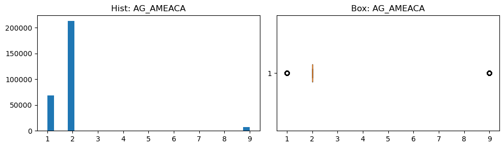

```
AG_AMEACA count    288630.000000
mean          1.931559
std           1.189013
min           1.000000
25%           2.000000
50%           2.000000
75%           2.000000
max           9.000000
Name: AG_AMEACA, dtype: float64
```

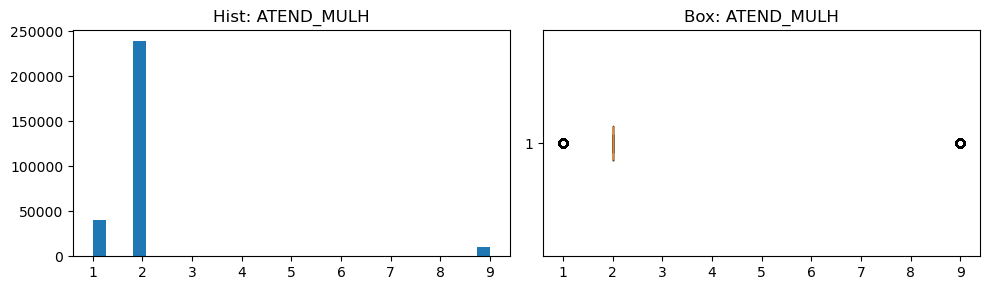

```
ATEND_MULH count    289921.000000
mean          2.112272
std           1.372149
min           1.000000
25%           2.000000
50%           2.000000
75%           2.000000
max           9.000000
Name: ATEND_MULH, dtype: float64
```

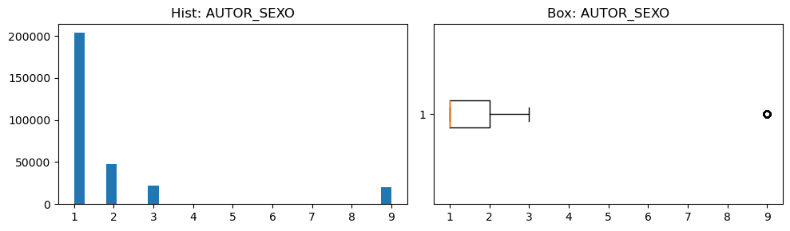

```
AUTOR_SEXO count    293941.000000
mean          1.871250
std           2.041562
min           1.000000
25%           1.000000
50%           1.000000
75%           2.000000
max           9.000000
Name: AUTOR_SEXO, dtype: float64
```

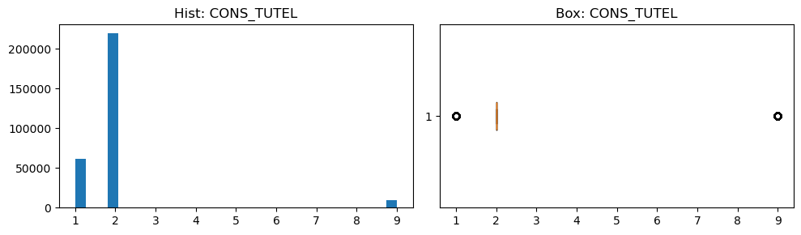

```
CONS_TUTEL count    289896.000000
mean          2.017306
std           1.344503
min           1.000000
25%           2.000000
50%           2.000000
75%           2.000000
max           9.000000
Name: CONS_TUTEL, dtype: float64
```

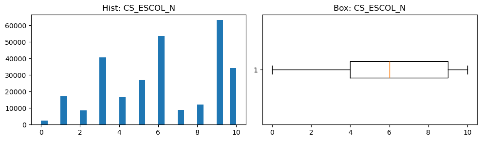

```
CS_ESCOL_N count    284501.000000
mean          6.147005
std           2.830182
min           0.000000
25%           4.000000
50%           6.000000
75%           9.000000
max          10.000000
Name: CS_ESCOL_N, dtype: float64
```

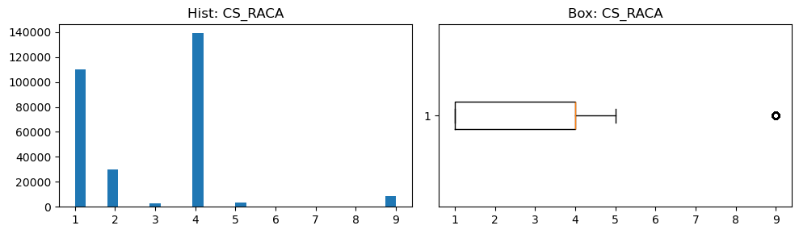

```
CS_RACA count    293834.000000
mean          2.821671
std           1.774995
min           1.000000
25%           1.000000
50%           4.000000
75%           4.000000
max           9.000000
Name: CS_RACA, dtype: float64
```

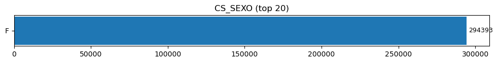

```
CS_SEXO count     294393
unique         1
top            F
freq      294393
Name: CS_SEXO, dtype: object
```

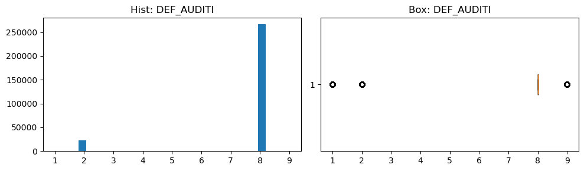

```
DEF_AUDITI count    291566.000000
mean          7.504003
std           1.664094
min           1.000000
25%           8.000000
50%           8.000000
75%           8.000000
max           9.000000
Name: DEF_AUDITI, dtype: float64
```

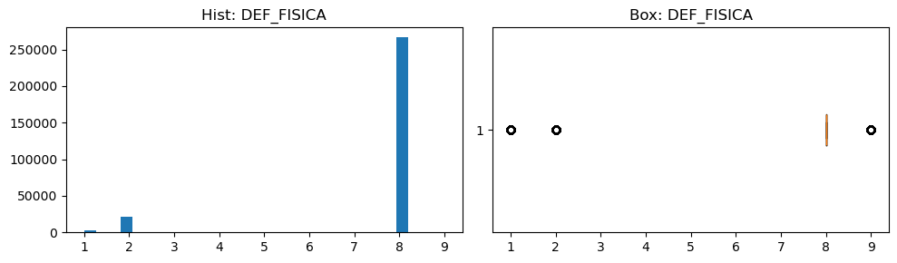

```
DEF_FISICA count    291623.000000
mean          7.494436
std           1.692611
min           1.000000
25%           8.000000
50%           8.000000
75%           8.000000
max           9.000000
Name: DEF_FISICA, dtype: float64
```

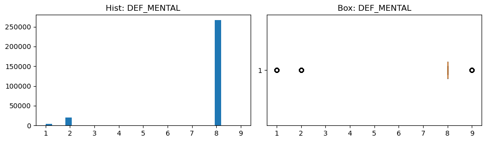

```
DEF_MENTAL count    291588.000000
mean          7.496910
std           1.693767
min           1.000000
25%           8.000000
50%           8.000000
75%           8.000000
max           9.000000
Name: DEF_MENTAL, dtype: float64
```

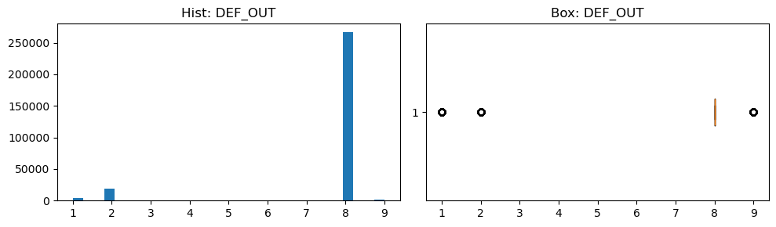

```
DEF_OUT count    291306.000000
mean          7.508201
std           1.682789
min           1.000000
25%           8.000000
50%           8.000000
75%           8.000000
max           9.000000
Name: DEF_OUT, dtype: float64
```

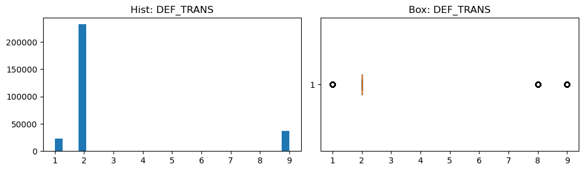

```
DEF_TRANS count    292832.000000
mean          2.801941
std           2.367443
min           1.000000
25%           2.000000
50%           2.000000
75%           2.000000
max           9.000000
Name: DEF_TRANS, dtype: float64
```

[44 more figures not shown]

[output not shown]

```python
import numpy as np
import pandas as pd
import matplotlib.pyplot as plt

TOP_N = 20

num_cols = cleaned_df.select_dtypes(include=np.number).columns
cat_cols = cleaned_df.columns.difference(num_cols)

def plot_col(c):
    s = cleaned_df[c].dropna()
    if s.empty:
        return

    sn = pd.to_numeric(s, errors="coerce").dropna()

    if not sn.empty:  # numérica
        fig, ax = plt.subplots(1, 2, figsize=(10, 3))
        ax[0].hist(sn, bins=30)
        ax[0].set_title(f"Hist: {c}")
        ax[1].boxplot(sn, vert=False)
        ax[1].set_title(f"Box: {c}")
        plt.tight_layout()
        plt.show()
        print(c, sn.describe())
    else:  # categórica
        vc = s.astype(str).str.strip().replace({"": np.nan}).value_counts(dropna=False).head(TOP_N)
        vc = vc.sort_values(ascending=True)  # barh: maior em cima
        fig, ax = plt.subplots(figsize=(10, 0.35*len(vc)+1))
        bars = ax.barh(vc.index.astype(str), vc.values)
        ax.set_title(f"{c} (top {TOP_N})")
        ax.bar_label(bars, padding=3, fontsize=9)
        plt.tight_layout()
        plt.show()
        print(c, s.describe())

# roda pra todas (ou use cleaned_df.columns[:10] pra testar)
for c in cleaned_df.columns:
    plot_col(c)
```